# Homework 4

Ryan Wang

## Resampling

For this assignment, we will be working with **two** of our previously used data sets – one for classification and one for regression. For the classification problem, our goal is (once again) to predict which passengers would survive the Titanic shipwreck. For the regression problem, our goal is (also once again) to predict abalone age.

Load the data from `data/titanic.csv` and `data/abalone.csv` into *R* and refresh your memory about the variables they contain using their attached codebooks.

Make sure to change `survived` and `pclass` to factors, as before, and make sure to generate the `age` variable as `rings` + 1.5!

*Remember that you’ll need to set a seed at the beginning of the document to reproduce your results.*

### Section 1: Regression (abalone age)

#### Question 1

Follow the instructions from Homework 2 to split the data set, stratifying on the outcome variable, `age`. You can choose the proportions to split the data into. Use *k*-fold cross-validation to create 5 folds from the training set.

```r
abalone_split <- initial_split(abalone,prop=0.70,strata = age)
abalone_train <- training(abalone_split)
abalone_test <- testing(abalone_split)
nrow(abalone_train) / (nrow(abalone_test) + nrow(abalone_train))  # check the proportion
```

```
## [1] 0.6995451
```

```r
abalone_folds <- vfold_cv(abalone_train, v = 5, strata = age)
```

Set up the same recipe from Homework 2.

```r
abalone_train_no_rings <- abalone_train%>% select(-rings) # exclude rings

abalone_recipe <- recipe(age ~ ., data = abalone_train_no_rings) %>%
  step_dummy(all_nominal_predictors()) %>%   # dummy code the categorical predictors
  step_interact(terms = ~ starts_with("type"):shucked_weight +  # dummy variables
                  longest_shell:diameter +
                 shucked_weight:shell_weight) %>%  # create interactions

  step_center(all_predictors()) %>%  # center predictors

  step_scale(all_predictors())  # scale predictors
```

#### Question 2

In your own words, explain what we are doing when we perform *k*-fold cross-validation:

- What **is** *k*-fold cross-validation?

K-fold cross-validation resamples the data so that the data are randomly splitted into k folds. For each fold, it acts as a ‘testing set’ while the other k-1 folds combined act as a ‘training set’. This process is repeated for k times and the resulting MSE or AUC value can be used to assess the model.

- Why should we use it, rather than simply comparing our model results on the entire training set?

Comparing the model result on the entire training set is likely to cause overfitting. Thus, a good model performance on the training data does not guarantee a good performance on the testing data.

- If we split the training set into two and used one of those two splits to evaluate/compare our models, what resampling method would we be using?

The validation set approach.

#### Question 3

Set up workflows for three models:

1. *k*-nearest neighbors with the `kknn` engine, tuning `neighbors`;
2. linear regression;
3. elastic net **linear** regression, tuning `penalty` and `mixture`.

```r
# 1
knn_mod_aba <- nearest_neighbor(neighbors = tune()) %>%
  set_mode("regression") %>%
  set_engine("kknn")

knn_wkflow_aba <- workflow() %>%
  add_model(knn_mod_aba) %>%
  add_recipe(abalone_recipe)

# 2
lm_mod_aba <- linear_reg() %>%
  set_engine("lm")

lm_wflow_aba <- workflow() %>%
  add_model(lm_mod_aba) %>%
  add_recipe(abalone_recipe)

# 3
en_mod_aba <- linear_reg(mixture = tune(),
                              penalty = tune()) %>%
  set_mode("regression") %>%
  set_engine("glmnet")

en_wflow_aba <- workflow() %>%
  add_model(en_mod_aba) %>%
  add_recipe(abalone_recipe)
```

Use `grid_regular` to set up grids of values for all of the parameters we’re tuning. Use values of `neighbors` from $1$ to $10$, the default values of penalty, and values of mixture from $0$ to $1$. Set up 10 levels of each.

```r
neighbors_grid_KNN <- grid_regular(neighbors(range = c(1, 10)), levels = 10)

en_grid <- grid_regular(penalty(range = c(0, 1),
                                     trans = identity_trans()),
                        mixture(range = c(0, 1)),
                             levels = 10)
```

How many models total, **across all folds**, will we be fitting to the **abalone** **data**? To answer, think about how many folds there are, how many combinations of model parameters there are, and how many models you’ll fit to each fold.

#### Question 4

Fit all the models you created in Question 3 to your folded data.

*Suggest using `tune_grid()`; see the documentation and examples included for help by running `?tune_grid`*. *You can also see the code in **Lab 4** for help with the tuning process.*

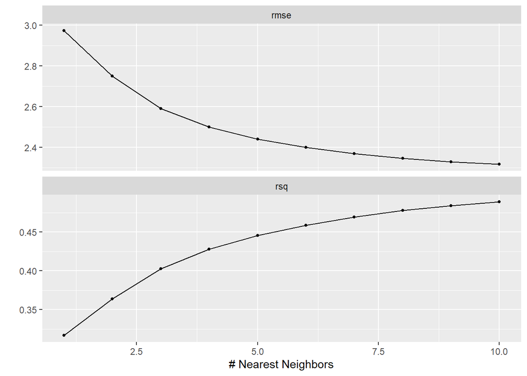

```r
# KNN
tune_res_aba_KNN <- tune_grid(
  object = knn_wkflow_aba,
  resamples = abalone_folds,
  grid = neighbors_grid_KNN)

autoplot(tune_res_aba_KNN)
```

```r
show_best(tune_res_aba_KNN, metric = "rmse")
```

```
## # A tibble: 5 × 7
##   neighbors .metric .estimator  mean     n std_err .config
##       <int> <chr>   <chr>      <dbl> <int>   <dbl> <chr>
## 1        10 rmse    standard    2.32     5  0.0577 Preprocessor1_Model10
## 2         9 rmse    standard    2.33     5  0.0589 Preprocessor1_Model09
## 3         8 rmse    standard    2.35     5  0.0603 Preprocessor1_Model08
## 4         7 rmse    standard    2.37     5  0.0616 Preprocessor1_Model07
## 5         6 rmse    standard    2.40     5  0.0623 Preprocessor1_Model06
```

```r
show_best(tune_res_aba_KNN, metric = "rsq")
```

```
## # A tibble: 5 × 7
##   neighbors .metric .estimator  mean     n std_err .config
##       <int> <chr>   <chr>      <dbl> <int>   <dbl> <chr>
## 1        10 rsq     standard   0.489     5  0.0133 Preprocessor1_Model10
## 2         9 rsq     standard   0.484     5  0.0137 Preprocessor1_Model09
## 3         8 rsq     standard   0.478     5  0.0141 Preprocessor1_Model08
## 4         7 rsq     standard   0.469     5  0.0145 Preprocessor1_Model07
## 5         6 rsq     standard   0.459     5  0.0146 Preprocessor1_Model06
```

```r
select_by_one_std_err(tune_res_aba_KNN, desc(neighbors), metric = "rmse")
```

```
## # A tibble: 1 × 9
##   neighbors .metric .estimator  mean     n std_err .config          .best .bound
##       <int> <chr>   <chr>      <dbl> <int>   <dbl> <chr>            <dbl>  <dbl>
## 1        10 rmse    standard    2.32     5  0.0577 Preprocessor1_M…  2.32   2.37
```

```r
select_by_one_std_err(tune_res_aba_KNN, desc(neighbors), metric = "rsq")
```

```
## # A tibble: 1 × 9
##   neighbors .metric .estimator  mean     n std_err .config          .best .bound
##       <int> <chr>   <chr>      <dbl> <int>   <dbl> <chr>            <dbl>  <dbl>
## 1        10 rsq     standard   0.489     5  0.0133 Preprocessor1_M… 0.489  0.476
```

The best model among all the KNN models is the one with neighbor = 10 as it has the highest $R^2$ value of 0.489 and the lowest RMSE of 2.32.

```r
# Linear regression
aba_lm_cv <- lm_wflow_aba %>% fit_resamples(abalone_folds)
```

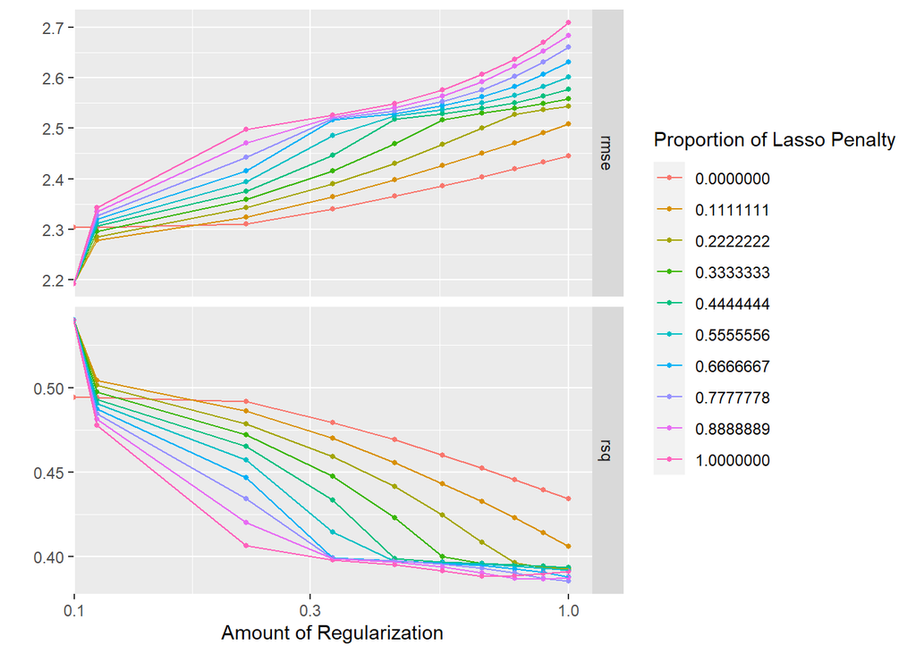

```r
# Elastic net
tune_res_ala_EN <- tune_grid(
 object = en_wflow_aba,
  resamples = abalone_folds,
  grid = en_grid)

autoplot(tune_res_ala_EN)
```

```r
show_best(tune_res_ala_EN, metric = "rmse", n = 10)
```

```
## # A tibble: 10 × 8
##    penalty mixture .metric .estimator  mean     n std_err .config
##      <dbl>   <dbl> <chr>   <chr>      <dbl> <int>   <dbl> <chr>
##  1   0       0.222 rmse    standard    2.19     5  0.0510 Preprocessor1_Model021
##  2   0       0.556 rmse    standard    2.19     5  0.0511 Preprocessor1_Model051
##  3   0       0.333 rmse    standard    2.19     5  0.0510 Preprocessor1_Model031
##  4   0       0.444 rmse    standard    2.19     5  0.0511 Preprocessor1_Model041
##  5   0       0.667 rmse    standard    2.19     5  0.0510 Preprocessor1_Model061
##  6   0       0.778 rmse    standard    2.19     5  0.0509 Preprocessor1_Model071
##  7   0       0.889 rmse    standard    2.19     5  0.0509 Preprocessor1_Model081
##  8   0       1     rmse    standard    2.19     5  0.0508 Preprocessor1_Model091
##  9   0       0.111 rmse    standard    2.19     5  0.0508 Preprocessor1_Model011
## 10   0.111   0.111 rmse    standard    2.28     5  0.0482 Preprocessor1_Model012
```

```r
show_best(tune_res_ala_EN, metric = "rsq", n = 10)
```

```
## # A tibble: 10 × 8
##    penalty mixture .metric .estimator  mean     n std_err .config
##      <dbl>   <dbl> <chr>   <chr>      <dbl> <int>   <dbl> <chr>
##  1   0       0.556 rsq     standard   0.540     5  0.0112 Preprocessor1_Model051
##  2   0       0.444 rsq     standard   0.540     5  0.0112 Preprocessor1_Model041
##  3   0       0.222 rsq     standard   0.540     5  0.0112 Preprocessor1_Model021
##  4   0       0.333 rsq     standard   0.540     5  0.0111 Preprocessor1_Model031
##  5   0       0.667 rsq     standard   0.540     5  0.0112 Preprocessor1_Model061
##  6   0       0.778 rsq     standard   0.540     5  0.0112 Preprocessor1_Model071
##  7   0       0.889 rsq     standard   0.540     5  0.0111 Preprocessor1_Model081
##  8   0       1     rsq     standard   0.540     5  0.0111 Preprocessor1_Model091
##  9   0       0.111 rsq     standard   0.540     5  0.0112 Preprocessor1_Model011
## 10   0.111   0.111 rsq     standard   0.504     5  0.0146 Preprocessor1_Model012
```

```r
select_by_one_std_err(tune_res_ala_EN,
                          metric = "rmse",
                          penalty,
                          mixture)
```

```
## # A tibble: 1 × 10
##   penalty mixture .metric .estimator  mean     n std_err .config    .best .bound
##     <dbl>   <dbl> <chr>   <chr>      <dbl> <int>   <dbl> <chr>      <dbl>  <dbl>
## 1       0   0.111 rmse    standard    2.19     5  0.0508 Preproces…  2.19   2.24
```

```r
select_by_one_std_err(tune_res_ala_EN,
                          metric = "rsq",
                          penalty,
                          mixture)
```

```
## # A tibble: 1 × 10
##   penalty mixture .metric .estimator  mean     n std_err .config    .best .bound
##     <dbl>   <dbl> <chr>   <chr>      <dbl> <int>   <dbl> <chr>      <dbl>  <dbl>
## 1       0   0.111 rsq     standard   0.540     5  0.0112 Preproces… 0.540  0.529
```

The best model among all the elastic net models is the one with penalty = 0 and mixture = 0.111 (mixture does not actually matter here) as it has the highest $R^2$ value of 0.540 and the lowest RMSE of 2.19.

#### Question 5

Use `collect_metrics()` to print the mean and standard errors of the performance metric *root mean squared error (RMSE)* for each model across folds.

Decide which of the models has performed the best. Explain how/why you made this decision. Note that each value of the tuning parameter(s) is considered a different model; for instance, KNN with $k = 4$ is one model, KNN with $k = 2$ another.

```r
a <- collect_metrics(tune_res_aba_KNN)
b <- collect_metrics(aba_lm_cv)
c <- collect_metrics(tune_res_ala_EN)

subset(a, .metric %in% c("rmse"))
```

```
## # A tibble: 10 × 7
##    neighbors .metric .estimator  mean     n std_err .config
##        <int> <chr>   <chr>      <dbl> <int>   <dbl> <chr>
##  1         1 rmse    standard    2.97     5  0.0611 Preprocessor1_Model01
##  2         2 rmse    standard    2.75     5  0.0633 Preprocessor1_Model02
##  3         3 rmse    standard    2.59     5  0.0641 Preprocessor1_Model03
##  4         4 rmse    standard    2.50     5  0.0641 Preprocessor1_Model04
##  5         5 rmse    standard    2.44     5  0.0632 Preprocessor1_Model05
##  6         6 rmse    standard    2.40     5  0.0623 Preprocessor1_Model06
##  7         7 rmse    standard    2.37     5  0.0616 Preprocessor1_Model07
##  8         8 rmse    standard    2.35     5  0.0603 Preprocessor1_Model08
##  9         9 rmse    standard    2.33     5  0.0589 Preprocessor1_Model09
## 10        10 rmse    standard    2.32     5  0.0577 Preprocessor1_Model10
```

```r
subset(b, .metric %in% c("rmse"))
```

```
## # A tibble: 1 × 6
##   .metric .estimator  mean     n std_err .config
##   <chr>   <chr>      <dbl> <int>   <dbl> <chr>
## 1 rmse    standard    2.19     5  0.0511 Preprocessor1_Model1
```

```r
subset(c, .metric %in% c("rmse"))
```

```
## # A tibble: 100 × 8
##    penalty mixture .metric .estimator  mean     n std_err .config
##      <dbl>   <dbl> <chr>   <chr>      <dbl> <int>   <dbl> <chr>
##  1   0           0 rmse    standard    2.30     5  0.0472 Preprocessor1_Model001
##  2   0.111       0 rmse    standard    2.30     5  0.0472 Preprocessor1_Model002
##  3   0.222       0 rmse    standard    2.31     5  0.0471 Preprocessor1_Model003
##  4   0.333       0 rmse    standard    2.34     5  0.0474 Preprocessor1_Model004
##  5   0.444       0 rmse    standard    2.37     5  0.0479 Preprocessor1_Model005
##  6   0.556       0 rmse    standard    2.39     5  0.0483 Preprocessor1_Model006
##  7   0.667       0 rmse    standard    2.40     5  0.0488 Preprocessor1_Model007
##  8   0.778       0 rmse    standard    2.42     5  0.0492 Preprocessor1_Model008
##  9   0.889       0 rmse    standard    2.43     5  0.0496 Preprocessor1_Model009
## 10   1           0 rmse    standard    2.44     5  0.0499 Preprocessor1_Model010
## # … with 90 more rows
```

The linear regression with no penalty is the best as it has the highest $R^2$ value of 0.540 and the lowest RMSE of 2.19.

#### Question 6

Use `finalize_workflow()` and `fit()` to fit your chosen model to the entire **training set**.

Lastly, use `augment()` to assess the performance of your chosen model on your **testing set**. Compare your model’s **testing** RMSE to its average RMSE across folds.

```r
final_fit_aba <- fit(lm_wflow_aba, abalone_train)

augment(final_fit_aba, new_data = abalone_test) %>%
  rmse(truth = age, estimate = .pred)
```

```
## # A tibble: 1 × 3
##   .metric .estimator .estimate
##   <chr>   <chr>          <dbl>
## 1 rmse    standard        2.10
```

The testing RMSE is 2.10, which is slightly low than the RMSE across folds.

### Section 2: Classification (Titanic survival)

#### Question 7

Follow the instructions from Homework 3 to split the data set, stratifying on the outcome variable, `survived`. You can choose the proportions to split the data into. Use *k*-fold cross-validation to create 5 folds from the training set.

```r
set.seed(26)
t_split <- initial_split(titanic, prop = 0.70, strata = survived)
t_train <- training(t_split)
t_test <- testing(t_split)

t_folds <- vfold_cv(t_train, v = 5, strata = survived)
```

#### Question 8

Set up the same recipe from Homework 3 – but this time, add `step_upsample()` so that there are equal proportions of the `Yes` and `No` levels (you’ll need to specify the appropriate function arguments). *Note: See Lab 5 for code/tips on handling imbalanced outcomes.*

```r
t_recipe <- recipe(survived ~ pclass + sex + age + sib_sp + parch + fare, data = t_train) %>%
  step_impute_linear(age, impute_with = imp_vars(sib_sp, parch)) %>%
  step_dummy(all_nominal_predictors()) %>%
  step_interact(terms= ~ starts_with("Sex"):fare + age:fare) %>%
  step_upsample(survived, over_ratio = 1)
```

#### Question 9

Set up workflows for three models:

1. *k*-nearest neighbors with the `kknn` engine, tuning `neighbors`;
2. logistic regression;
3. elastic net **logistic** regression, tuning `penalty` and `mixture`.

Set up the grids, etc. the same way you did in Question 3. Note that you can use the same grids of parameter values without having to recreate them.

```r
# 1
knn_mod_t <- nearest_neighbor(neighbors = tune()) %>%
  set_mode("classification") %>%
  set_engine("kknn")

knn_wkflow_t <- workflow() %>%
  add_model(knn_mod_t) %>%
  add_recipe(t_recipe)

# 2
lg_mod_t <- logistic_reg() %>%
set_engine("glm")

lg_wflow_t <- workflow() %>%
  add_model(lg_mod_t) %>%
  add_recipe(t_recipe)

# 3
en_mod_t <- logistic_reg(mixture = tune(),
                              penalty = tune()) %>%
  set_mode("classification") %>%
  set_engine("glmnet")

en_wflow_t <- workflow() %>%
  add_model(en_mod_t) %>%
  add_recipe(t_recipe)
```

#### Question 10

Fit all the models you created in Question 9 to your folded data.

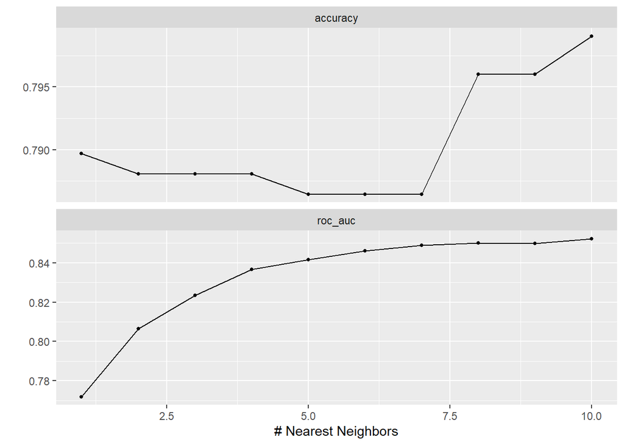

```r
# KNN
tune_res_t_KNN <- tune_grid(
  object = knn_wkflow_t,
  resamples = t_folds,
  grid = neighbors_grid_KNN)

autoplot(tune_res_t_KNN)
```

```r
show_best(tune_res_t_KNN, metric = "roc_auc")
```

```
## # A tibble: 5 × 7
##   neighbors .metric .estimator  mean     n std_err .config
##       <int> <chr>   <chr>      <dbl> <int>   <dbl> <chr>
## 1        10 roc_auc binary     0.852     5  0.0118 Preprocessor1_Model10
## 2         8 roc_auc binary     0.850     5  0.0117 Preprocessor1_Model08
## 3         9 roc_auc binary     0.850     5  0.0116 Preprocessor1_Model09
## 4         7 roc_auc binary     0.849     5  0.0119 Preprocessor1_Model07
## 5         6 roc_auc binary     0.846     5  0.0127 Preprocessor1_Model06
```

```r
select_by_one_std_err(tune_res_t_KNN, desc(neighbors), metric = "roc_auc")
```

```
## # A tibble: 1 × 9
##   neighbors .metric .estimator  mean     n std_err .config          .best .bound
##       <int> <chr>   <chr>      <dbl> <int>   <dbl> <chr>            <dbl>  <dbl>
## 1        10 roc_auc binary     0.852     5  0.0118 Preprocessor1_M… 0.852  0.841
```

The best model among all the KNN models is the one with neighbor = 10 as it has the greatest area under the ROC curve, 0.852.

```r
# Linear regression
t_lg_cv <- lg_wflow_t %>% fit_resamples(t_folds)
```

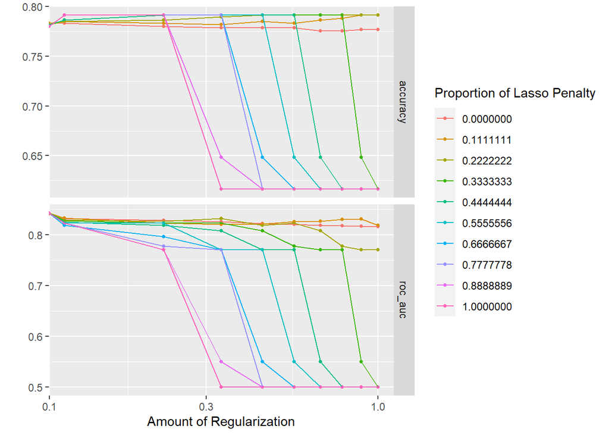

```r
# Elastic net
tune_res_t_EN <- tune_grid(
  object = en_wflow_t,
  resamples = t_folds,
  grid = en_grid
)

autoplot(tune_res_t_EN)
```

```r
show_best(tune_res_t_EN, metric = "roc_auc")
```

```
## # A tibble: 5 × 8
##   penalty mixture .metric .estimator  mean     n std_err .config
##     <dbl>   <dbl> <chr>   <chr>      <dbl> <int>   <dbl> <chr>
## 1       0   0.667 roc_auc binary     0.842     5  0.0123 Preprocessor1_Model061
## 2       0   0.778 roc_auc binary     0.842     5  0.0123 Preprocessor1_Model071
## 3       0   0.889 roc_auc binary     0.842     5  0.0123 Preprocessor1_Model081
## 4       0   1     roc_auc binary     0.842     5  0.0122 Preprocessor1_Model091
## 5       0   0.222 roc_auc binary     0.842     5  0.0124 Preprocessor1_Model021
```

```r
select_by_one_std_err(tune_res_t_EN,
                          metric = "roc_auc",
                          penalty,
                          mixture
                          )
```

```
## # A tibble: 1 × 10
##   penalty mixture .metric .estimator  mean     n std_err .config    .best .bound
##     <dbl>   <dbl> <chr>   <chr>      <dbl> <int>   <dbl> <chr>      <dbl>  <dbl>
## 1       0       0 roc_auc binary     0.841     5  0.0142 Preproces… 0.842  0.830
```

#### Question 11

Use `collect_metrics()` to print the mean and standard errors of the performance metric *area under the ROC curve* for each model across folds.

Decide which of the models has performed the best. Explain how/why you made this decision.

```r
d <- collect_metrics(tune_res_t_KNN)
e <- collect_metrics(t_lg_cv)
f <- collect_metrics(tune_res_t_EN)

subset(d, .metric %in% c("roc_auc"))
```

```
## # A tibble: 10 × 7
##    neighbors .metric .estimator  mean     n std_err .config
##        <int> <chr>   <chr>      <dbl> <int>   <dbl> <chr>
##  1         1 roc_auc binary     0.772     5  0.0162 Preprocessor1_Model01
##  2         2 roc_auc binary     0.806     5  0.0129 Preprocessor1_Model02
##  3         3 roc_auc binary     0.823     5  0.0139 Preprocessor1_Model03
##  4         4 roc_auc binary     0.837     5  0.0120 Preprocessor1_Model04
##  5         5 roc_auc binary     0.842     5  0.0122 Preprocessor1_Model05
##  6         6 roc_auc binary     0.846     5  0.0127 Preprocessor1_Model06
##  7         7 roc_auc binary     0.849     5  0.0119 Preprocessor1_Model07
##  8         8 roc_auc binary     0.850     5  0.0117 Preprocessor1_Model08
##  9         9 roc_auc binary     0.850     5  0.0116 Preprocessor1_Model09
## 10        10 roc_auc binary     0.852     5  0.0118 Preprocessor1_Model10
```

```r
subset(e, .metric %in% c("roc_auc"))
```

```
## # A tibble: 1 × 6
##   .metric .estimator  mean     n std_err .config
##   <chr>   <chr>      <dbl> <int>   <dbl> <chr>
## 1 roc_auc binary     0.841     5  0.0120 Preprocessor1_Model1
```

```r
subset(f, .metric %in% c("roc_auc"))
```

```
## # A tibble: 100 × 8
##    penalty mixture .metric .estimator  mean     n std_err .config
##      <dbl>   <dbl> <chr>   <chr>      <dbl> <int>   <dbl> <chr>
##  1   0           0 roc_auc binary     0.841     5  0.0142 Preprocessor1_Model001
##  2   0.111       0 roc_auc binary     0.832     5  0.0141 Preprocessor1_Model002
##  3   0.222       0 roc_auc binary     0.828     5  0.0131 Preprocessor1_Model003
##  4   0.333       0 roc_auc binary     0.825     5  0.0128 Preprocessor1_Model004
##  5   0.444       0 roc_auc binary     0.822     5  0.0129 Preprocessor1_Model005
##  6   0.556       0 roc_auc binary     0.820     5  0.0129 Preprocessor1_Model006
##  7   0.667       0 roc_auc binary     0.819     5  0.0132 Preprocessor1_Model007
##  8   0.778       0 roc_auc binary     0.817     5  0.0130 Preprocessor1_Model008
##  9   0.889       0 roc_auc binary     0.817     5  0.0129 Preprocessor1_Model009
## 10   1           0 roc_auc binary     0.816     5  0.0127 Preprocessor1_Model010
## # … with 90 more rows
```

The KNN model with neighbor = 10 is the best as it has the highest area under the ROC curve of 0.852.

#### Question 12

Use `finalize_workflow()` and `fit()` to fit your chosen model to the entire **training set**.

Lastly, use `augment()` to assess the performance of your chosen model on your **testing set**. Compare your model’s **testing** ROC AUC to its average ROC AUC across folds.

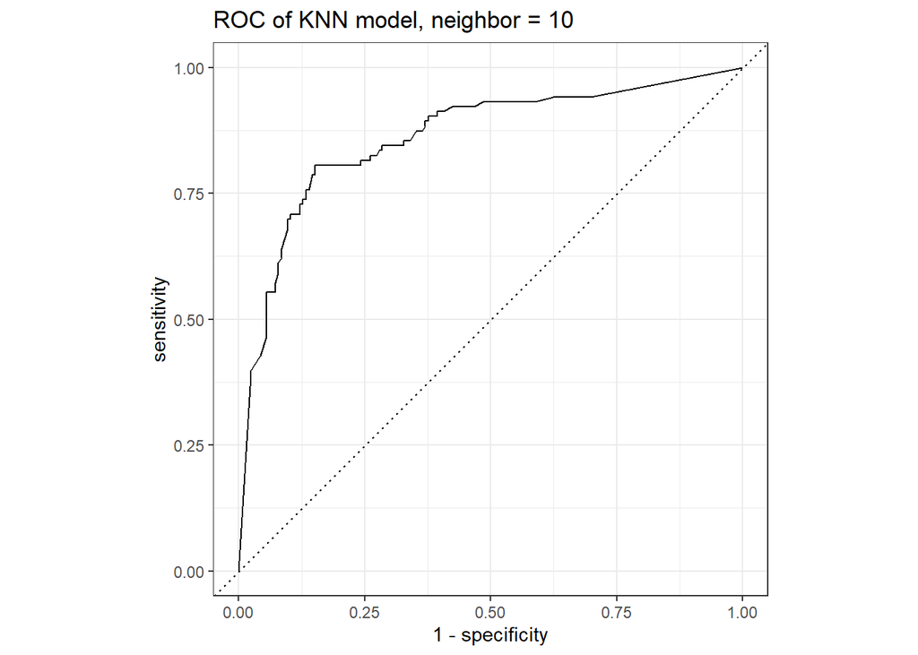

```r
best_neighbors <- select_by_one_std_err(tune_res_t_KNN, desc(neighbors), metric = "roc_auc")
final_wf_t <- finalize_workflow(knn_wkflow_t, best_neighbors)
final_fit_t <- fit(final_wf_t, t_train)

augment(final_fit_t, new_data = t_test) %>%
  roc_curve(truth = survived, estimate = .pred_Yes) %>%
autoplot() + labs(title = 'ROC of KNN model, neighbor = 10')
```

```r
augment(final_fit_t, new_data = t_test) %>%
  roc_auc(truth = survived, estimate = .pred_Yes)
```

```
## # A tibble: 1 × 3
##   .metric .estimator .estimate
##   <chr>   <chr>          <dbl>
## 1 roc_auc binary         0.862
```

The testing ROC AUC is 0.862, which is slightly higher than the average ROC AUC across folds.

## Required for 231 Students

Consider the following intercept-only model, with $\epsilon \sim N(0, \sigma^2)$:

$$Y=\beta+\epsilon$$

where $\beta$ is the parameter that we want to estimate. Suppose that we have $n$ observations of the response, i.e. $y_{1}, ..., y_{n}$, with uncorrelated errors.

### Question 13

Derive the least-squares estimate of $\beta$.

### Question 14

Suppose that we perform leave-one-out cross-validation (LOOCV). Recall that, in LOOCV, we divide the data into $n$ folds.

Derive the covariance between $\hat{\beta}^{(1)}$, or the least-squares estimator of $\beta$ that we obtain by taking the first fold as a training set, and $\hat{\beta}^{(2)}$, the least-squares estimator of $\beta$ that we obtain by taking the second fold as a training set?

[figure not shown]